# hw3p2

## Homework 3, Problem 2 on homogeneous Poisson processes

ECE C143A/C243A, Spring Quarter 2023, Prof. J.C. Kao, TAs T. Monsoor, R. Gore, D. Singla

## Background

The goal of this notebook is to model a neuron as a homogeneous Poisson processes and evaluate its properties. We will consider a simulated neuron that has a cosine tuning curve described in equation (1.15) in *TN* (*TN* refers to *Theoretical Neuroscience* by Dayan and Abbott.)

$$\lambda(s) = r_0 + (r_\text{max} - r_0)\cos(s-s_\text{max})$$

where $\lambda$ is the firing rate (in spikes per second), $s$ is the reaching angle of the arm, $s_\text{max}$ is the reaching angle associated with the maximum response $r_\text{max}$, and $r_0$ is an offset that shifts the tuning curve up from the zero axis. This will be refered as tuning equation in the following questions.

Let $r_0=35$, $r_\text{max}=60$, and $s_\text{max}=\pi/2$.

Note: If you are not as familiar with Python, be aware that if 1 is of type `int`, then 1 / a where a is any `int` greater than 1 will return 0, rather than a real number between 0 and 1. This is because Python will return an `int` if both inputs are `int`s. If instead you write 1.0 / a, you will get out the desired output, since 1.0 is of type `float`.

```python
"""
ECE C143/C243 Homework-3 Problem-2

"""
import numpy as np
import matplotlib.pyplot as plt
import nsp as nsp # these are helper functions that we provide.
import scipy.special
import scipy.stats

# Load matplotlib images inline
%matplotlib inline

# Reloading any code written in external .py files.
%load_ext autoreload
%autoreload 2
```

### (a) (6 points) Spike trains

For each of the following reaching condition ($s=k \cdot \pi/4$, where $k = 0,1,\ldots,7$), generate 100 spike trains according to a homogeneous Poisson process. Each spike train should have a duration of 1 second. You can think of each of each spike train sequence as a trial. Therefore, we generate 100 trials of the neuron spiking according to a homogeneous Poisson Process for 8 reach directions.

Your code for this section should populate a 2D `numpy` array, `spike_times` which has dimensions `num_cons` $\times$ `num_trials` (i.e., it is $8 \times 100$). Each element of this 2D numpy array is a numpy array containing the spike times for the neuron on a given condition and trial. Note that this array may have a different length for each trial.

e.g., `spike_times.shape` should return `(8, 100)` and `spike_times[0,0]` should return the spike times on the first trial for a reach to the target at $0$ degrees. In one instantiation, our code returns that `spike_times[0,0]` is:

```
array([   0.        ,    5.94436383,   10.85691999,   26.07821145,
         50.02836141,   67.417219  ,   74.2948356 ,  119.19210112,
        139.41789878,  176.59511596,  244.40788916,  267.3643421 ,
        288.42590046,  324.3770265 ,  340.26911602,  407.75730065,
        460.76250631,  471.23773964,  489.41659607,  514.60180131,
        548.71822693,  565.6036432 ,  586.20557118,  601.11595447,
        710.37485206,  751.60837895,  879.93536952,  931.26983289,
        944.1130483 ,  949.38455374,  963.22509374,  964.67365483,
        966.3865719 ,  974.3657882 ,  987.25729081])
```

Of course, this varies based off of random seed. Also note that time at 0 is not a spike.

```python
## 2a
bin_width = 20                             # (ms)
s = np.arange(8)*np.pi/4                   # (radians)
num_cons = np.size(s)                      # num_cons = 8 in this case, number of directions
r_0 = 35 # (spikes/s)
r_max = 60 # (spikes/s)
s_max = np.pi/2 # (radians)
T = 1000 #trial length (ms)
num_trials = 100 # number of spike trains to generate

tuning = r_0 + (r_max-r_0)*np.cos(s-s_max) # tuning curve
spike_times = np.empty((num_cons, num_trials), dtype=list)

def findfiringrate(angle: int) -> float:
    return r_0 + (r_max-r_0)*np.cos(angle-s_max) # tuning curve

for con in range(num_cons):
    angle = s[con]
    for rep in range(num_trials):
        firingrate = findfiringrate(angle)
        spike_times[con, rep] = nsp.GeneratePoissonSpikeTrain(T, firingrate)
```

```python
# ### MY FUNCTION IMPLEMENTATION ## IGNORE

# ## 2a
# bin_width = 20                             # (ms)
# s = np.arange(8)*np.pi/4                   # (radians)
# num_cons = np.size(s)                      # num_cons = 8 in this case, number of directions
# r_0 = 35 # (spikes/s)
# r_max = 60 # (spikes/s)
# s_max = np.pi/2 # (radians)
# T = 1000 #trial length (ms)
# num_trials = 100 # number of spike trains to generate

# tuning = r_0 + (r_max-r_0)*np.cos(s-s_max) # tuning curve
# spike_times = np.empty((num_cons, num_trials), dtype=list)

# def findfiringrate(angle: int) -> float:
#     return r_0 + (r_max-r_0)*np.cos(angle-s_max) # tuning curve

# for con in range(num_cons):
#     firingrate = findfiringrate(s[con])
#     t = 0
#     tau = 1

#     for rep in range(num_trials):
#         #====================================================#
#         list_spiketimes = []

#         while (t < tau):
#             sample = np.random.exponential(scale=(1.0/firingrate))
#             t += sample
#             #print("sample is", sample)
#             list_spiketimes.append(sample)

#         #====================================================#
#         spike_times[con, rep] = list
#         pass
#         #====================================================#
#         # END YOUR CODE
#         #====================================================#
```

```
(8, 100)
```

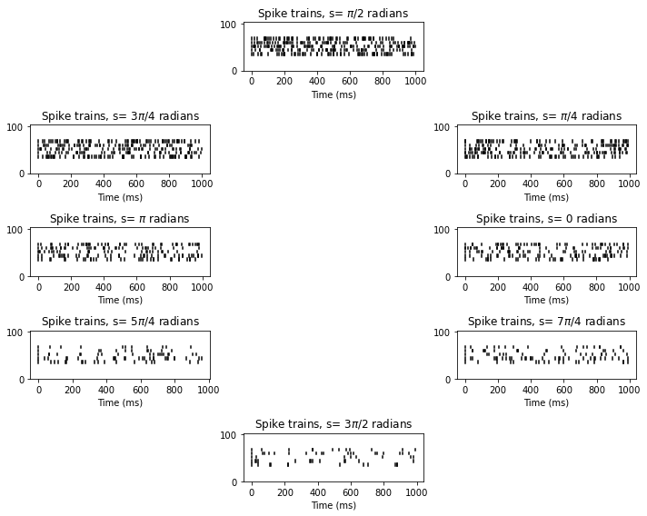

```python
print(spike_times.shape)

s_labels = ['0', '$\pi$/4', '$\pi$/2', '3$\pi$/4', '$\pi$', '5$\pi$/4', '3$\pi$/2', '7$\pi$/4']
num_plot_rows = 5
num_plot_cols = 3
subplot_indx = [9, 6, 2, 4, 7, 10, 14, 12]
num_rasters_to_plot = 5 # per condition

# Generate and plot homogeneous Poisson process spike trains
plt.figure(figsize=(10,8))
for con in range(num_cons):

    # Plot spike rasters
    plt.subplot(num_plot_rows, num_plot_cols, subplot_indx[con])
    nsp.PlotSpikeRaster(spike_times[con, 0:num_rasters_to_plot])

    plt.title('Spike trains, s= '+s_labels[con]+' radians')
    plt.tight_layout()
```

### Plotting the spike rasters.

The following code plot 5 spike trains for each reaching angle in the same format as shown in Figure 1.6(A) in *TN*. You should take a look at this code to understand what it's doing. You may also want to look at the `PlotSpikeRaster` function from `nsp`.

The plots should make intuitive sense given the tuning parameters.

### (b) (5 points) Plot spike histograms

For each reaching angle, find the spike histogram by taking spike counts in non-overlapping 20 ms bins, then averaging across the 100 trials. Plot the 8 resulting spike histograms around a circle, as in part (a). This time, as we'll allow you to represent the data as you like, you will have to also plot each histogram on your own. The spike histograms should have firing rate (in spikes / second) as the vertical axis and time (in msec, not time bin index) as the horizontal axis.

Suggestion: you can use plt.bar to plot the histogram, it is important to set the `width` for this function, e.g. width = 12.

```
[  0.          29.37663443  99.43395052 139.36342453 156.54212912
 197.27728062 202.19766896 268.44125135 274.87619869 291.76224511
 334.26861788 352.912235   366.60167652 442.54985728 455.67918855
 481.67457743 528.46632611 643.63825215 670.58999163 675.55315465
 675.99598196 676.34749813 690.53090848 718.9115343  760.14514394
 791.99616938 843.47495505 850.20835556 853.34409685 862.59885437
 885.92781867 891.03989836 892.92497101 906.83628892 947.67472374
 987.43406424]
```

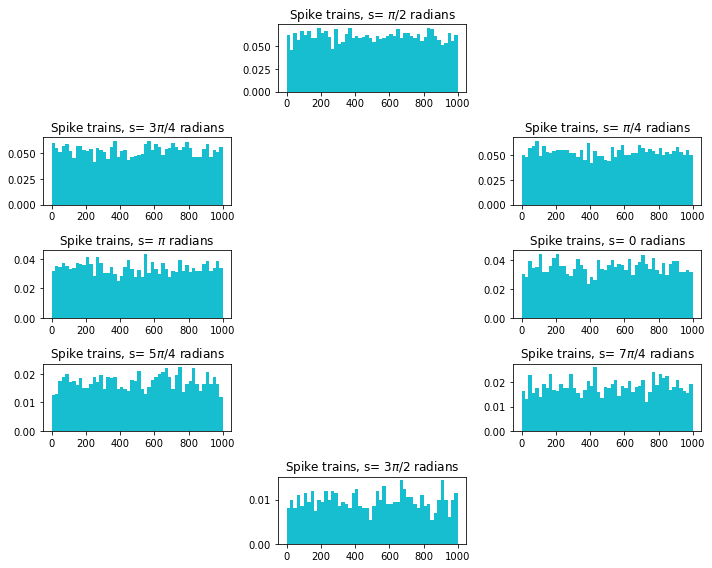

```python
## 2b

plt.figure(figsize=(10,8))

print(spike_times[0,1])

bin_width = 20 #ms
num_bins = int(T / bin_width)


# initialise the arrays to hold the binned spike counts and rates
binned_spike_counts = np.zeros((num_cons, num_trials, num_bins), dtype = int)
binned_spike_rates = np.zeros((num_cons, num_bins))

# compute the bin edges, with small epsilon value to avoid 0
eps = 0.000001
bin_edges = np.arange(num_bins+1) * bin_width + eps

# loop over the angles and trials

for con in range(num_cons):
    plt.subplot(num_plot_rows,num_plot_cols,subplot_indx[con])

    for trial in range(num_trials):

        # get spike times for current angle and trial
        spike_train = spike_times[con, trial]

        # bin the spike times
        binned_counts, _ = np.histogram(spike_train, bin_edges)

        # store the binned spike counts
        binned_spike_counts[con, trial] = binned_counts


        # compute the average binned spike counts across trials

        binned_spike_rates[con] = np.mean(binned_spike_counts[con], axis = 0) / bin_width

        bin_time_centers = bin_edges[:-1] + bin_width / 2

        # plot the binned spike counts across trials

        plt.bar(bin_time_centers, binned_spike_rates[con], width=bin_width)

    #====================================================#
    pass

    #====================================================#
    # END YOUR CODE
    #====================================================#
    plt.title('Spike trains, s= '+s_labels[con]+' radians')
    plt.tight_layout()

plt.show()
```